# M.3.Unsupervised - Iris dataset - Davis Zakary

## `Stage.2.Feature.Extraction`

**`Tasks`**

1. Stage.2.Task.1 - List the four Iris dataset features available.
2. Stage.2.Task.2 - Read the provided abstract on feature extraction.
3. Stage.2.Task.3 - Reflect on your current strategy for storing skilling information and generate ideas in discourse what you can do going forward.
4. Stage.2.Task.4 - Write 2-4 bullets
- Discuss the mechanics of recalling feature extraction methods for future use.
- Share your current approach to storing skilling info future plans. `Note: There is no coding in stage.2.`

`Learning moment`

- Data s cience requires building and maintaining your toolbox on a daily basis.
- Take ownership of your work as no one else will do it for you.
- When your manager requests something by 8AM, they expect results by noon, not 5PM.
- Reflect on your current strategy and use class discourse to share insights with your peers. `Professor Brain Full` uses Google Sheets size 14 rows, ~300 columns.

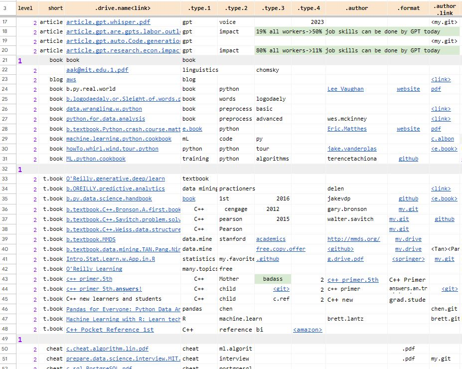

### Stage.2.Task => ALL

#### Task 1

The four features are sepal width, sepal length, petal width, petal lenght.

#### Task 3

Currently, I organize bookmarks in my browser using folders. These bookmarks store links to websites or local PDFs that contain data science related skills. This is mostly because I have been too lazy to put together a more robust tracker, such as a spreadsheet. Going forward, I could create an excel file with notes regarding the content, what I thought was useful, and where it is located within the text if the text is long like a book.

#### Task 4

When recalling feature extraction methods, I typically start with a handful of methods at the top of my head such. As I look at the data, I then decide if I need to Google more advanced tools. Usually I have a goal in mind and search for the tool I can use to accomplish that goal.

Going forward, it would be nice to keep track of what techniques I have used in previous projects to extract data. When working on a new project, I could scan through this anecdotal list to give my brain a quick refresher. The important part would be not just having a list of techniques, but also a short description that refreshes the brain.

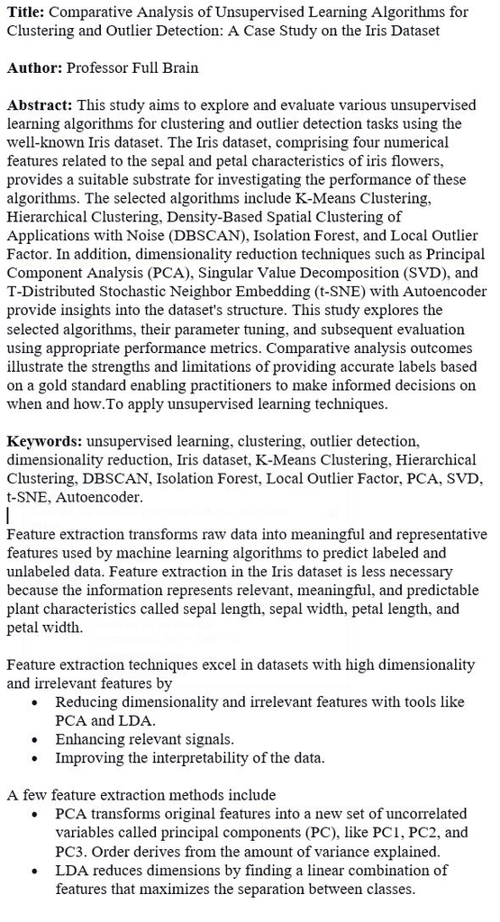

## Stage.3.Data Scaling

`Stage.3.Task`

A. Perform scaling and visualize outcomes. B. Notate and curious issues or discriminating factors.

1. K-Means Clustering
2. Hierarchical Clustering
3. Density-Based Spatial Clustering of Applications w Noise
4. Isolation Forest
5. Local Outlier Factor
6. Principal Component Analysis
7. Singular Value Decomposition
8. T-Distributed Stochastic Neighbor Embedding With Autoencoder
9. Singular Value Decomposition

### Stage.3.Task => ALL

I will use t-sne and PCA methods to extract estimators from the data. For both methods, I will compress the four provided variables into two predictors. This will allow the predictors to be plotted on a standard scatterplot.

```python
from sklearn.manifold import TSNE
```

```
(150, 2)
0.16879567503929138
```

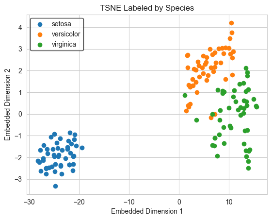

```python
iris_tsne = TSNE(n_components=2)
embedded = iris_tsne.fit_transform(df_no_species)
print(embedded.shape)
print(iris_tsne.kl_divergence_)
for name in species:
    idx = (df['species'] == name).to_numpy()
    plt.scatter(embedded[idx, 0], embedded[idx, 1], label=name)
plt.title('TSNE Labeled by Species')
plt.legend(edgecolor='black')
plt.xlabel('Embedded Dimension 1')
plt.ylabel('Embedded Dimension 2')
plt.show()
```

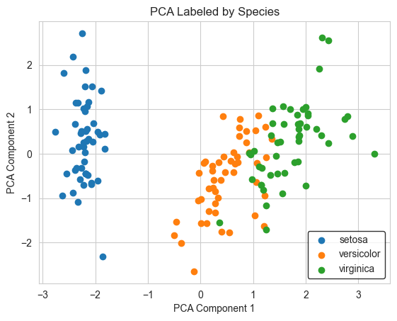

```python
iris_pca = PCA(n_components=2)
pca_data = iris_pca.fit_transform(df_no_species)
for name in species:
    idx = (df['species'] == name).to_numpy()
    plt.scatter(pca_data[idx, 0], pca_data[idx, 1], label=name)
plt.title('PCA Labeled by Species')
plt.legend(edgecolor='black')
plt.xlabel('PCA Component 1')
plt.ylabel('PCA Component 2')
plt.show()
```

Both TSNE and PCA are able to clearly separate the setosa from the versicolor and virginica in the resultant feature space. With TSNE, the setosa datapoints are more tightly grouped into a sphere, while PCA has some outliers near the bottom of the graph.

However, the main point of concern is the boundary between versicolor and virginica. When transforming the data, we want our classifier to be able to have the best chance at discriminating between these two categories.

It appears that TSNE does a slightly better job at seperating these two classes. Visually, I can draw a hyperplane on the TSNE plot that would incorrectly classify 1 virginica and 4 versicolor points. A quick inspection of the PCA plot puts doubt in my mind that I would be able to accomplish the same for the PCA transformation.

**`Stage.3`** - Expected Outcomes

- Combination plot provides guidance on desired outcomes.
- You're not required to generate a combined plot but ensure to visualize outcomes.
- As a refresher, note any curious issues or discriminating factors.
- Indicate scaling issues and/or unaddressed bias.

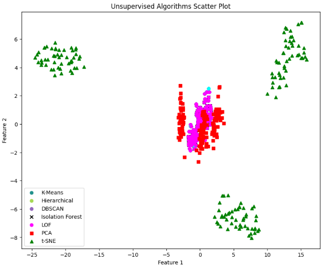

## `Stage.4.Machine.Learning and Evaluation`

**`Tasks`**

1. Perform train_test_split.
2. Fit data to the training set.
3. Generate predicted outcomes.
4. Evaluate performance with cross-validation.
5. Compute the confusion matrix.
6. In place of stage.5 - Visualization => Provide a brief 1-2 paragraph of algorithmic performance.
- K-Means
- Hierarchical
- DBSCAN - use ===> `Silhouette Score` <- This is the only evaluation you need to do for your analysis of cluster quality.
- Isolation Forest
- LOF
- PCA
- SVD
- t-SNE

**`Learning Moment`**

- ensure you have addressed labels to serve your solution.
- https://scikit-learn.org/stable/modules/generated/sklearn.preprocessing.LabelEncoder.html

```
df.columns
Index(['Id', 'SepalLengthCm', 'SepalWidthCm', 'PetalLengthCm',
 'PetalWidthCm','Species', 'species_label'], dtype='object')
```

```python
from sklearn.cluster import AgglomerativeClustering, DBSCAN
from sklearn.model_selection import train_test_split
from sklearn.metrics import silhouette_score, accuracy_score, confusion_matrix
species_map = {'setosa': 0, 'versicolor': 1, 'virginica': 2}
x = df_no_species.to_numpy()
y = (df['species'].map(species_map)).to_numpy()
print(y[0:10])
```

```
[0 0 0 0 0 0 0 0 0 0]
```

### Stage.4.Task => ALL

I will use hierarchical clustering and DBSCAN to classify my data.

Not sure why we need to do a train/test split for unsupervised algorithms... the clustering methods are not applied to more data after being fitted.

```python
x_train, x_test, y_train, y_test = train_test_split(
    x, y, test_size=0.2, random_state=42, stratify=y
)
print(x_train.shape, x_test.shape)
print(y_train.shape, y_test.shape)
print(np.unique_counts(y_train))
```

```
(120, 4) (30, 4)
(120,) (30,)
UniqueCountsResult(values=array([0, 1, 2]), counts=array([40, 40, 40]))
```

```python
hiearch = AgglomerativeClustering(n_clusters=3)
labels = hiearch.fit_predict(x)
print('Silhouette Score: ', silhouette_score(x, labels))

# Compare labels against known truth
# It is possible that class labels are not the same... try rotating them
accuracy = []
for i in range(3):
    adjusted = (labels + i) % 3
    accuracy.append(accuracy_score(y, adjusted))
print(accuracy)
print('Accuracy: ', max(accuracy))
```

```
Silhouette Score:  0.44553956399200406
[0.013333333333333334, 0.16, 0.8266666666666667]
Accuracy:  0.8266666666666667
```

```python
adjusted = (labels + 2) % 3
print(confusion_matrix(y, adjusted))
```

```
[[49  1  0]
 [ 0 27 23]
 [ 0  2 48]]
```

```python
dbscan = DBSCAN(eps=0.7)
labels = dbscan.fit_predict(x)
print('Silhouette Score: ', silhouette_score(x, labels))

# Since we can't specify number of classes, check unique labels
labels += 1
print(np.unique_counts(labels))

# Compare labels against known truth
# It is possible that class labels are not the same... try rotating them
accuracy = []
for i in range(3):
    adjusted = (labels + i) % 3
    accuracy.append(accuracy_score(y, adjusted))
print(accuracy)
print('Accuracy: ', max(accuracy))
```

```
Silhouette Score:  0.5191948417986468
UniqueCountsResult(values=array([0, 1, 2]), counts=array([ 8, 48, 94]))
[0.32, 0.013333333333333334, 0.6666666666666666]
Accuracy:  0.6666666666666666
```

```python
adjusted = (labels + 2) % 3
print(confusion_matrix(y, adjusted))
```

```
[[48  0  2]
 [ 0 48  2]
 [ 0 46  4]]
```

## Stage.5.Visualization

As a refresher,

- In lieu of stage.5 - Visualization provide a brief 1-2 paragraph of algorithmic performance in Stage.4.

In my experience, an unsupervised method is used if you do not already have class labels (the "Y"). Once you generate labels from clustering, you can then train a supervised classifier using this label. Then, you can apply your classifier to new data (the test set) and generate a confusion matrix based on performance. If you want to measure performance of the clustering algorithm, we can use silhouette score since we do not have ground truth labels.

In our case, we already have the class label. To evaluate the performance of the clustering algorithm itself, we can compare the cluster labels against the ground truth labels in addition to using silhouette score. While DBSCAN produces slightly better clusters according to silhouette score, hierarchical clustering produces labels that are more accurate when compared against the ground truth.

The confusion matrices show us that both clustering methods rarely confuse one of the classes. This is likely the setosa, as we saw how it exists far from the other two classes in feature space. For both methods, there is confucion between the versicolor and virginica species. For hierarchical clustering, 25 flowers are misclassified as the other species, while DBSCAN has 48 mis classifications.

It appears that DBSCAN is having trouble with finding two seperate classes within the versicolor and virginica "blob."